# Qualitative Predictors

Dr. Josh Jacobson

6 February 2026

*These lecture notes were originally developed by Dr. Kris Pruitt.*

The purpose of this lesson is to estimate and interpret a multiple linear regression model with a categorical predictor (explanatory) variable.

# Indicator Formulation

In our previous discussions of multiple linear regression the response and predictors were both continuous, numerical variables. Instead, we might like to use a *categorical* variable to predict a numerical response. However, this requires a slightly different approach since the predictor categories are generally represented by words rather than numbers. How do we write a regression equation with words?! The solution is to treat each category (level) as its own binary variable that is equal to 1 if the observation is in the category and 0 if it is not in the category. We call these artificial predictors **indicator** variables because they indicate which category is assigned.

Formally, if a predictor variable $z$ has values consisting of $k$ categories then the linear regression equation is defined below.

$$y=\beta_0 +\beta_1 z_1 +\beta_2 z_2 + ...+ \beta_{k-1} z_{k-1} +
\epsilon$$

In this equation, $z_i$ is equal to 1 if an observation is assigned a $z$ value equivalent to category $i$ and 0 otherwise. Furthermore, since an observation can only be assigned a single category, it must be true that:

$$z_1 + z_2 + ... + z_{k-1} \leq 1$$

There are two important items to note in this formulation. First, we only need to define $k-1$ indicator variables even though there are $k$ categories. This is because we use the intercept $\beta_0$ as a reference level. In other words, if an observation belongs to the $k$th category, then all of the $z_i$ values will be equal to 0 and only the intercept will remain. This also explains why we use an inequality in the constraint for the sum of the $z_i$ values. If an observation is in the $k$th category, then the sum of the $z_i$ values will be 0. Otherwise, the sum must be exactly equal to 1.

# Inferential Model

For this lesson we’ll use a data set regarding penguins in the Palmer Archipelago of Antarctica. Load the appropriate libraries and import the data set.

```r
# load libraries
library(palmerpenguins)

# import data
data(penguins)

# view data structure
glimpse(penguins)
```

```
## Rows: 344
## Columns: 8
## $ species           <fct> Adelie, Adelie, Adelie, Adelie, Adelie, Adelie, Adel…
## $ island            <fct> Torgersen, Torgersen, Torgersen, Torgersen, Torgerse…
## $ bill_length_mm    <dbl> 39.1, 39.5, 40.3, NA, 36.7, 39.3, 38.9, 39.2, 34.1, …
## $ bill_depth_mm     <dbl> 18.7, 17.4, 18.0, NA, 19.3, 20.6, 17.8, 19.6, 18.1, …
## $ flipper_length_mm <int> 181, 186, 195, NA, 193, 190, 181, 195, 193, 190, 186…
## $ body_mass_g       <int> 3750, 3800, 3250, NA, 3450, 3650, 3625, 4675, 3475, …
## $ sex               <fct> male, female, female, NA, female, male, female, male…
## $ year              <int> 2007, 2007, 2007, 2007, 2007, 2007, 2007, 2007, 2007…
```

```r
# remove missing observations
penguins2 <- penguins %>%
  na.omit()
```

Suppose we want to see if there is an association between the species of penguin (categorical) and the length of its flippers (numerical).

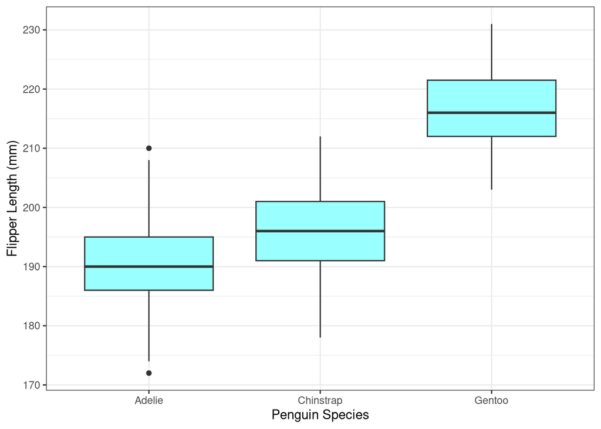

```r
ggplot(data = penguins2, aes(x = species, y = flipper_length_mm)) +
  geom_boxplot(fill = "#99FFFF") +
  labs(
    x = "Penguin Species",
    y = "Flipper Length (mm)"
  ) +
  theme_bw()
```

Based on the box plot, it does appear there is some association between species and flipper length. The predictor variable has three categories (species). So, based on our previous formulation, the linear regression equation only requires two indicator variables. One of the species will be left out as the reference category. In that case, the estimated regression equation would be:

$$\hat{y}=\hat{\beta}_0 + \hat{\beta}_1 \cdot \text{Chinstrap} +
\hat{\beta}_2 \cdot \text{Gentoo}$$

In this equation $\text{Chinstrap}$ and $\text{Gentoo}$ are binary indicator variables that add to at most 1. Just as with our previous discussion of regression equations, the $\hat{\beta}$ parameters are what we seek to estimate using the least squares method.

```r
# fit model
model1 <- lm(flipper_length_mm ~ species, data = penguins2)

# view estimated parameters
summary(model1)
```

```
##
## Call:
## lm(formula = flipper_length_mm ~ species, data = penguins2)
##
## Residuals:
##      Min       1Q   Median       3Q      Max
## -18.1027  -4.8235  -0.1027   4.7647  19.8973
##
## Coefficients:
##                  Estimate Std. Error t value Pr(>|t|)
## (Intercept)      190.1027     0.5522  344.25  < 2e-16 ***
## speciesChinstrap   5.7208     0.9796    5.84 1.25e-08 ***
## speciesGentoo     27.1326     0.8241   32.92  < 2e-16 ***
## ---
## Signif. codes:  0 '***' 0.001 '**' 0.01 '*' 0.05 '.' 0.1 ' ' 1
##
## Residual standard error: 6.673 on 330 degrees of freedom
## Multiple R-squared:  0.7747, Adjusted R-squared:  0.7734
## F-statistic: 567.4 on 2 and 330 DF,  p-value: < 2.2e-16
```

The resulting estimated regression equation is:

$$\hat{y}=190.10 + 5.72 \cdot \text{Chinstrap} + 27.13 \cdot \text{Gentoo}$$

Now let’s carefully interpret the meaning of this estimated regression equation. If a given penguin is an Adelie, then the Chinstrap and Gentoo predictors are both equal to zero and we estimate Adelies have an *average* flipper length of 190.10 mm. Below are some additional questions regarding this model.

- How do we interpret the other parameter estimates?
- Does the model appear to be a good fit based on RSE and R-squared?
- How should we interpret the results of the ANOVA?
- How should we interpret the p-values associated with each coefficient?

# Prediction Model

Now that we’ve determined the quality of the inferential model, we might like to use species to predict flipper length. In order to assess the accuracy of such a model, we first split the sample into training and testing sets.

```r
# randomly select training rows
set.seed(303)
rows <- sample(x = nrow(penguins2), size = floor(0.75 * nrow(penguins2)), replace = FALSE)

# extract training and testing sets
training <- penguins2[rows, ]
testing <- penguins2[-rows, ]
```

Now we fit the model to the training data and assess its accuracy using the testing data.

```r
# fit model to training set
model2 <- lm(flipper_length_mm ~ species, data = training)

# predict testing set
testing_pred <- testing %>%
  mutate(flipper_pred = predict(model2, newdata = testing))

# compute RMSE
testing_pred %>%
  summarize(RMSE = sqrt(mean((flipper_length_mm - flipper_pred)^2)))
```

| RMSE |
| --- |
| 7.022841 |

By only using species, we can predict a penguin’s flipper length to within about 7 mm. How does this compare to the null model that always predicts the mean flipper length?

```r
# compute mean response
flipper_avg <- mean(training$flipper_length_mm)

# compute RMSE for null model
testing %>%
  summarize(RMSE = sqrt(mean((flipper_length_mm - flipper_avg)^2)))
```

| RMSE |
| --- |
| 13.14753 |

Our species model performs much better than the null model. But, could we produce an even more accurate model by adding another predictor?

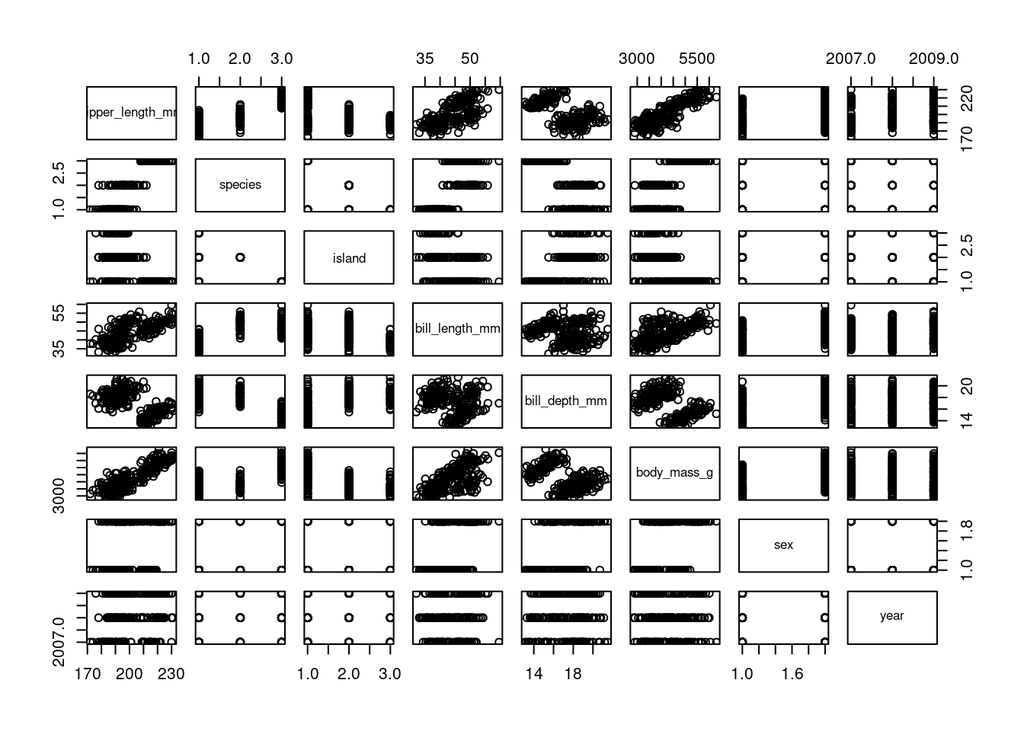

```r
pairs(flipper_length_mm ~ ., data = training)
```

Let’s try adding body mass to the model.

```r
# fit model to training set
model3 <- lm(flipper_length_mm ~ species + body_mass_g, data = training)

# predict testing set
testing %>%
  mutate(flipper_pred = predict(model3, newdata = testing)) %>%
  summarize(RMSE = sqrt(mean((flipper_length_mm - flipper_pred)^2)))
```

| RMSE |
| --- |
| 5.658665 |

With the additional information of body mass, we can decrease the error even further to about 5.7 mm. What is the form of this new model?

```r
# display summary output
summary(model3)
```

```
##
## Call:
## lm(formula = flipper_length_mm ~ species + body_mass_g, data = training)
##
## Residuals:
##      Min       1Q   Median       3Q      Max
## -14.3244  -3.4351   0.0882   3.5101  13.6511
##
## Coefficients:
##                   Estimate Std. Error t value Pr(>|t|)
## (Intercept)      1.597e+02  2.692e+00  59.317  < 2e-16 ***
## speciesChinstrap 6.398e+00  9.081e-01   7.045 1.87e-11 ***
## speciesGentoo    1.663e+01  1.262e+00  13.174  < 2e-16 ***
## body_mass_g      8.073e-03  7.142e-04  11.303  < 2e-16 ***
## ---
## Signif. codes:  0 '***' 0.001 '**' 0.01 '*' 0.05 '.' 0.1 ' ' 1
##
## Residual standard error: 5.34 on 245 degrees of freedom
## Multiple R-squared:  0.8624, Adjusted R-squared:  0.8607
## F-statistic: 511.7 on 3 and 245 DF,  p-value: < 2.2e-16
```

The equation for our new model is:

$$\hat{y}=159.7 + 6.4 \cdot \text{Chinstrap} + 16.6 \cdot \text{Gentoo} +
0.008 \cdot \text{Mass}$$

What is a 95% prediction interval for the flipper length of a single Chinstrap penguin with a body mass of 3.9 kilograms?